# Exercise Set 1 — Geoms and Aesthetics

Tom Carroll

## Exercise 1

These first few exercises will run through some of the simple principles of creating a ggplot2 object, assigning aesthetics mappings and geoms.

1. Read in the cleaned patients dataset as we saw in ggplot2 course earlier (“patients_clean_ggplot2.txt”)

```r
patients_clean <- read.delim("patients_clean_ggplot2.txt",sep="\t")
```

### Scatterplots

2. Using the patient dataset generate a scatter plot of BMI versus Weight.

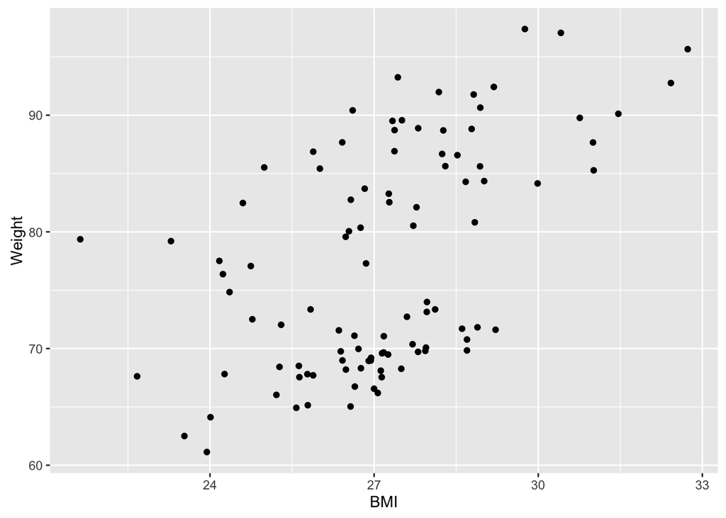

3. Extending the plot from exercise 2, add a colour scale to the scatterplot based on the Height variable.

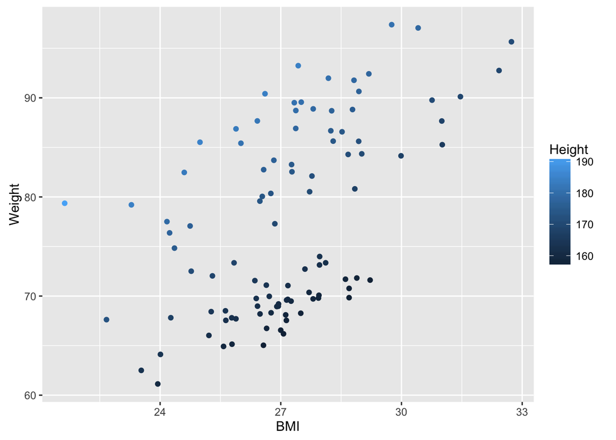

4. Following from exercise 3, split the BMI vs Weight plot into a grid of plots separated by Smoking status and Sex .

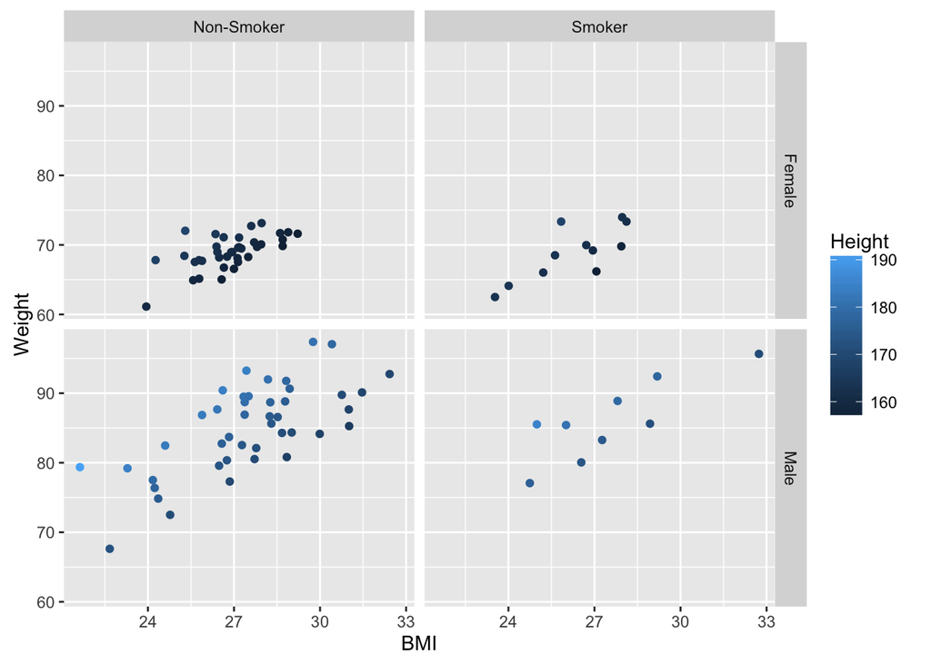

5. Using an additional geom, add an extra layer of a fit line to the solution from exercise 3.

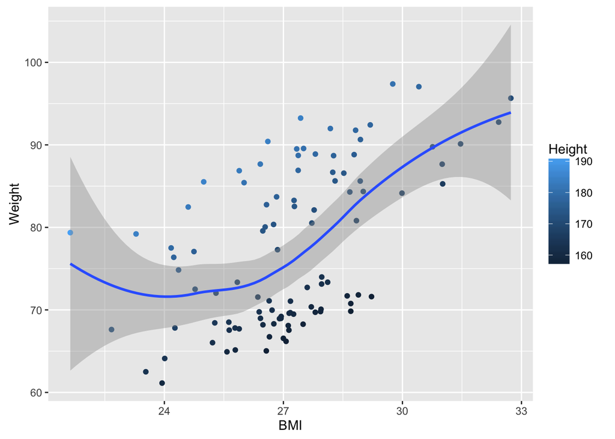

6. Does the fit in question 5 look good? Look at the description for ?geom_smooth() and adjust the method for a better fit.

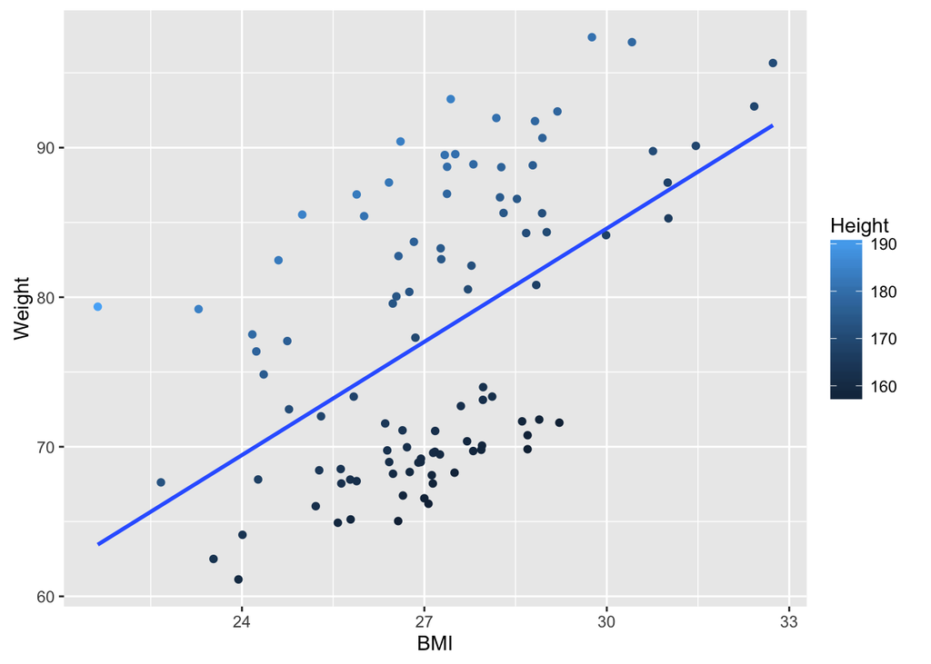

### Boxplots and Violin plots

7. Generate a boxplot of BMIs comparing smokers and non-smokers.

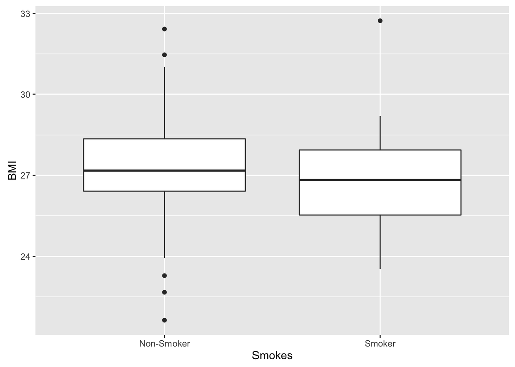

8. Following from the boxplot comparing smokers and non-smokers in exercise 7, colour boxplot edges by Sex.

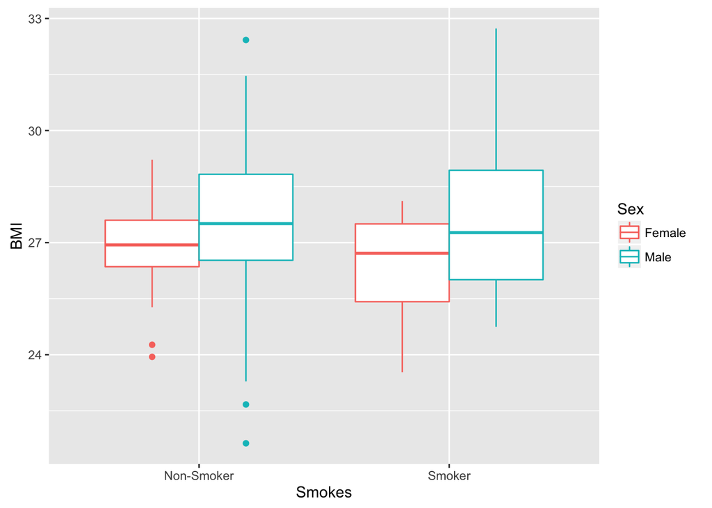

9. Now reproduce the boxplots in exercise 8 (grouped by smoker, coloured by sex) but now include a separate facet for people of different age (using Age column).

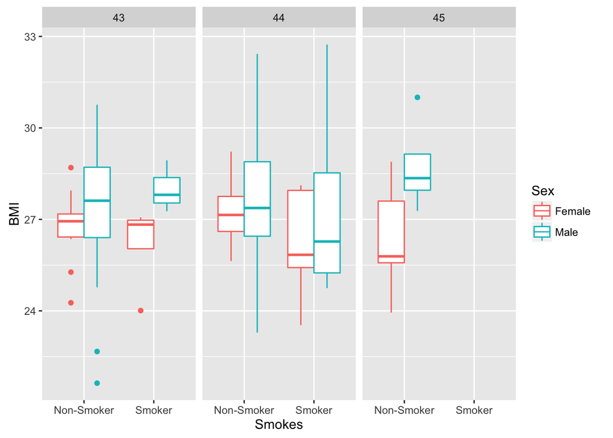

10. Produce a similar boxplot of BMIs but this time group data by Sex, colour by Age and facet by Smoking status.

HINT - Discrete values such as in factors are used for categorical data.

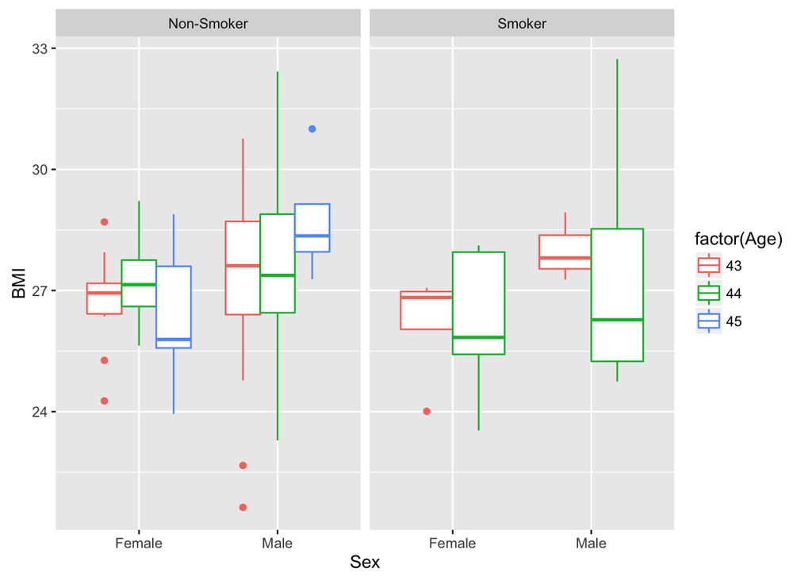

11. Regenerate the solution to exercise 10 but this time using a violin plot.

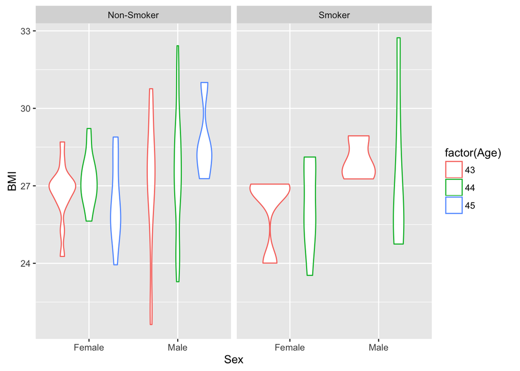

### Histogram and Density plots

12. Generate a histogram of BMIs with each bar coloured blue.

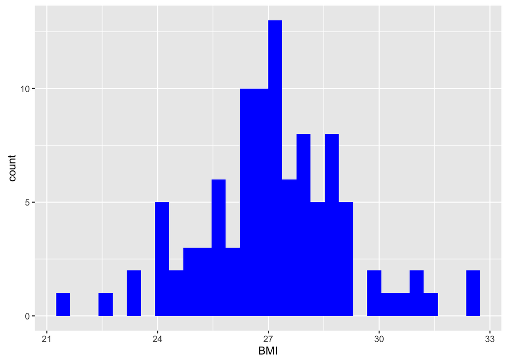

13. Generate density plots of BMIs coloured by Sex.

HINT: alpha can be used to control transparancy.

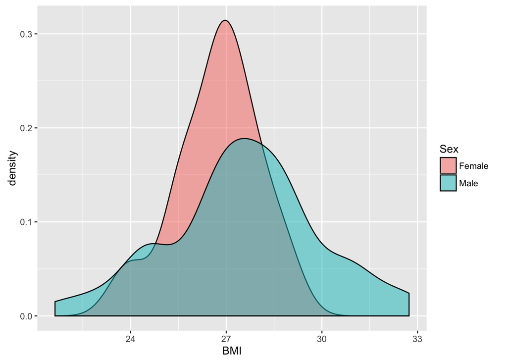

14. Generate a separate density plot of BMI coloured by sex for each Grade,

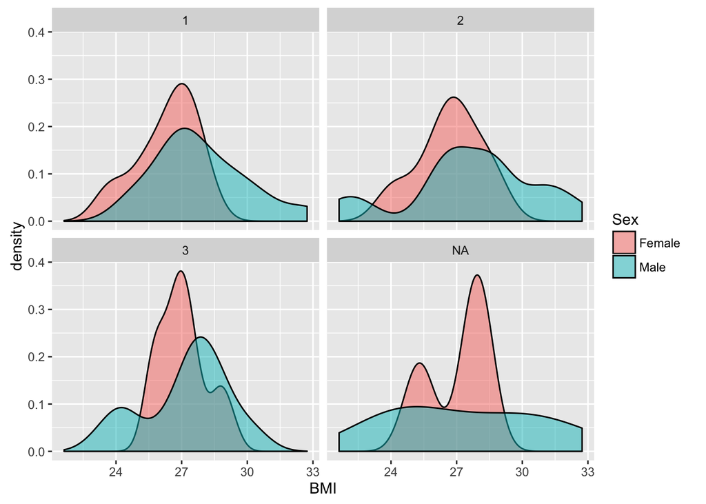